# Lab 2b

Data Visualization

Statistical programming with R

For this practical, you will need to load the packages `ggplot2`, `dplyr`, and `patchwork`. If displaying multiple plot in one figure, use the R chunk options `fig.width` (default = 7), `fig.height` (default = 5) and/or `fig.asp` (height:width ratio) to display the plots in a nice format. To avoid messages by `ggplot()` being printed to the html, set the global chunk option to `message = FALSE`

```r
library(ggplot2)
library(dplyr)
library(patchwork)
knitr::opts_chunk$set(message = FALSE)
```

For a quick reference of `ggplot2` functions, consult

- [ggplot2 Cheatsheet](https://raw.githubusercontent.com/rstudio/cheatsheets/main/data-visualization.pdf)
- [ggplot2 Reference](https://ggplot2.tidyverse.org/reference/index.html)

# The diamonds data

The dataset for this practical is the `diamonds` dataset from the package `ggplot2`.

1. Check the help page of this `tibble` for its content, and display the first 10 rows of the data in your HTML.

```r
diamonds
```

| carat | cut | color | clarity | depth | table | price | x | y | z |
| --- | --- | --- | --- | --- | --- | --- | --- | --- | --- |
| 0.23 | Ideal | E | SI2 | 61.5 | 55.0 | 326 | 3.95 | 3.98 | 2.43 |
| 0.21 | Premium | E | SI1 | 59.8 | 61.0 | 326 | 3.89 | 3.84 | 2.31 |
| 0.23 | Good | E | VS1 | 56.9 | 65.0 | 327 | 4.05 | 4.07 | 2.31 |
| 0.29 | Premium | I | VS2 | 62.4 | 58.0 | 334 | 4.20 | 4.23 | 2.63 |
| 0.31 | Good | J | SI2 | 63.3 | 58.0 | 335 | 4.34 | 4.35 | 2.75 |
| 0.24 | Very Good | J | VVS2 | 62.8 | 57.0 | 336 | 3.94 | 3.96 | 2.48 |
| 0.24 | Very Good | I | VVS1 | 62.3 | 57.0 | 336 | 3.95 | 3.98 | 2.47 |
| 0.26 | Very Good | H | SI1 | 61.9 | 55.0 | 337 | 4.07 | 4.11 | 2.53 |
| 0.22 | Fair | E | VS2 | 65.1 | 61.0 | 337 | 3.87 | 3.78 | 2.49 |
| 0.23 | Very Good | H | VS1 | 59.4 | 61.0 | 338 | 4.00 | 4.05 | 2.39 |

[output cut: 990 more lines]

The `diamonds` data set has more than 50.000 rows, which is a lot. To simplify matters, we will work with a random sample of 500 cases.

2. Set the seed to 100, and randomly sample 500 cases from the dataset `diamonds` using the `slice_sample()` function. Save the resulting data set as `my_diamonds`.

```r
set.seed(100)
my_diamonds <- slice_sample(diamonds, n = 500)
```

# One variable

In the following exercises we display plots numeric and of categorical/discrete variables. Check the `geoms` overview in the lecture sheets for the different options.

1. In a 1 x 3 plot array, plot the distribution of variable `carat` using the three different geoms. Add a title with the name of the appropriate geom to each plot. The chunk option `fig.asp = .35` displays the plots in a nice format.

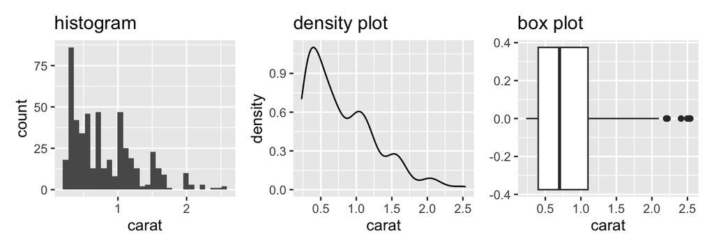

```r
p <- ggplot(my_diamonds, aes(x = carat))

p + geom_histogram(bins = ) +
    ggtitle("histogram") +

p + geom_density() +
    ggtitle("density plot") +

p + geom_boxplot() +
    ggtitle("box plot")
```

Discrete variables are variables with countable values (i.e. categorical variables or variables with a small number of integer values). The most common option for such variables is the bar plot

1. Display the bar plots of the factors `cut`, `color` and `clarity` in a 1 x 3 plot array. Make sure that the labels of the categories are readable (i.e., not overlapping).

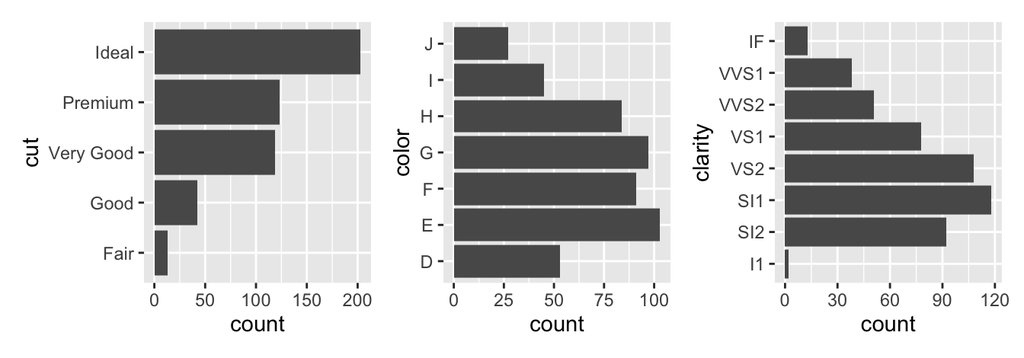

```r
  ggplot(my_diamonds, aes(y = cut)) +
    geom_bar() +

  ggplot(my_diamonds, aes(y = color)) +
    geom_bar() +

  ggplot(my_diamonds, aes(y = clarity)) +
    geom_bar()
```

# Two variables

The combinations between numeric and categorical/discrete variables requires different geoms. Check the cheat sheet again for the appropriate options.

1. In the first row of one figure, display a box and violin plot of the variables `price` and `cut`, an in the second row a density plot. Use the `/` symbol to start a new row.

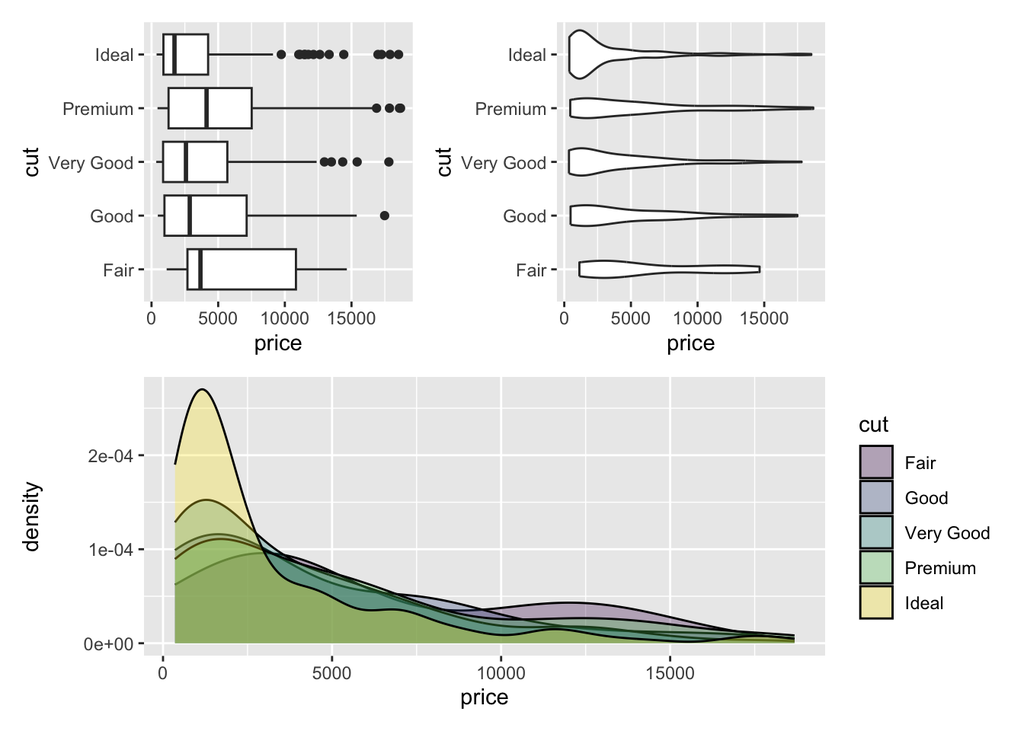

```r
(ggplot(my_diamonds, aes(price, cut)) +
    geom_boxplot() +

ggplot(my_diamonds, aes(price, cut)) +
    geom_violin() ) /

ggplot(my_diamonds, aes(price, fill = cut)) +
    geom_density(alpha = .3)
```

The variables `color` and `clarity` are both categorical variables, and their distribution is generally displayed by bar plots.

2. Display a stacked, a dodged, and a filled bar plot of these variables in a 1 x 3 plot array. Use the `plot_layout()` function to display the legend and axes labels only once.

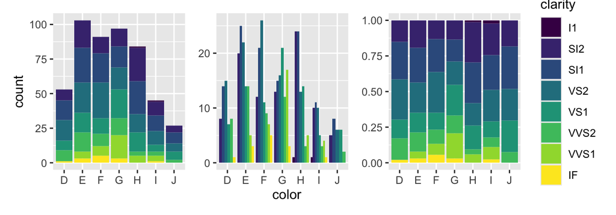

```r
ggplot(my_diamonds, aes(color, fill = clarity)) +
    geom_bar() +

ggplot(my_diamonds, aes(color, fill = clarity)) +
    geom_bar(position = "dodge") +

ggplot(my_diamonds, aes(color, fill = clarity)) +
    geom_bar(position = "fill") +

  plot_layout(guides = "collect", axes = "collect")
```

3. Now display the joint distribution of these two variables with `geom_count()`.

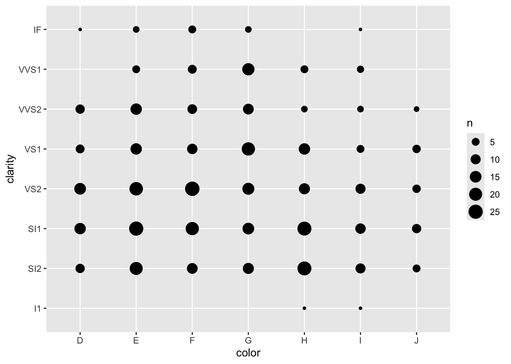

```r
ggplot(my_diamonds, aes(color, clarity)) +
    geom_count()
```

# Three variables

The most common plot is that with two numeric variables and one categorical variable, with the levels of the categorical variable displayed with different shapes or colors.

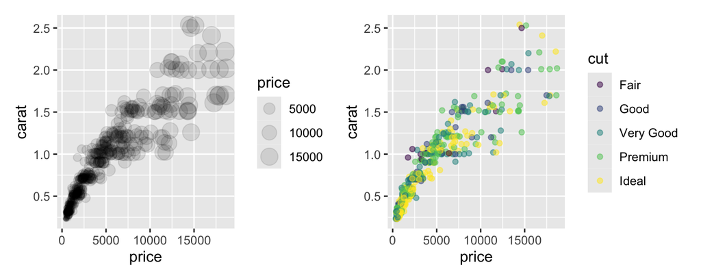

```r
ggplot(my_diamonds, aes(price, carat, size = price)) +
  geom_point(alpha = .1) +

ggplot(my_diamonds, aes(price, carat, col = cut)) +
  geom_point(alpha = .5)
```

2. The plot with different colors for `cut` is not very clear. Reproduce the plot by adding a `facet_wrap()` layer, and add `price` for the size of the points.

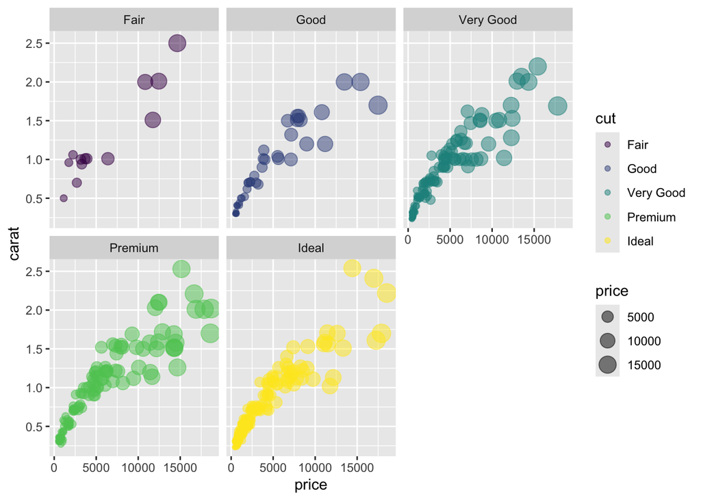

```r
ggplot(my_diamonds, aes(price, carat, col = cut)) +
  geom_point(aes(size = price), alpha = .5) +
  facet_wrap(vars(cut))
```

4. Display the previous plot with a different theme (choose one that you think looks nice).

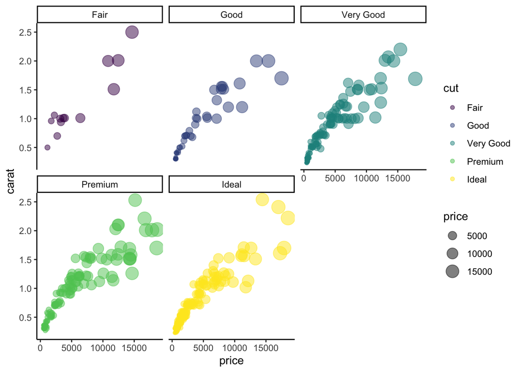

```r
ggplot(my_diamonds, aes(price, carat, col = cut)) +
  geom_point(aes(size = price), alpha = .5) +
  facet_wrap(vars(cut)) +
  theme_classic()
```

# Advanced

1. Display a graphical representation of the variables `price`, `carat`, `depth`, `cut` and `color`.

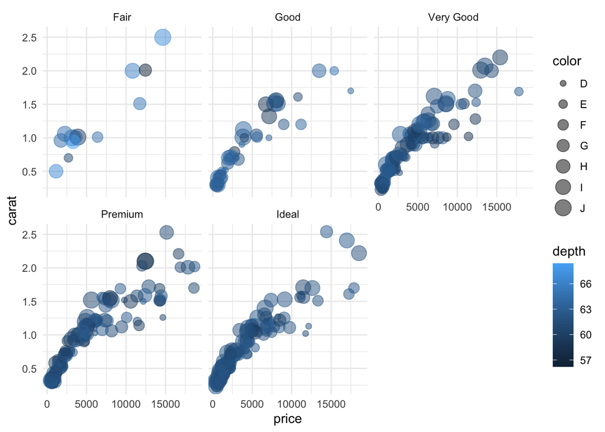

```r
ggplot(my_diamonds, aes(price, carat, col = depth)) +
  geom_point(aes(size = color), alpha = .5) +
  facet_wrap(vars(cut)) +
  theme_minimal()
```

End of lab